# VarTimeFeatures

This card explores the possible expansions of temporal data. Variables such as a date cannot be directly used in modeling. They need to be converted into something numeric or nominal. Another way of saying this is that we are seeking to encode the temporal data.

The types of temporal data that we are looking to encode into are:

| Type | Example | Class |
| --- | --- | --- |
| Simple Dates | 1995-05-23 | Date |
| Date & Times | 1995-05-23 16:44:00 | POSIXt |
| Quarters | Q2-1995 | yearquarter |
| Month | 07-1995 | yearmonth |
| Weeks | W15-1995 | yearweek |
| Quarters | Q2-1995 | yearquarter |
| Time | 16:44:00 | hms |

There are some issues to consider about this.

- How does daylight-saving affect times?
- What time-zone does the date/time apply to?
- What format should the dates and times be displayed as? AM/PM versus 24 hour clock? mm/dd/yyyy or dd/mm/yy or yyyy/mm/dd

Encodings fall into different types. The encoding to a number (integer or double) is the first. Encoding to pairs of cyclic (double) variables is the second. Encoding to sets of binary variables is the last.

### Numerical encodings

Since dates (and date&times) can be thought of as the numbers of days since some arbitrary origin, it is simple to encode dates and times into a number (whole numbers for dates, decimal values for date&times). The arbitrary origin is fixed at 1970-01-01 00:00:00

Times can be thought of as fragments of a day especially if they are part of a date&time variable. Times such as “hms” (which stands for Hours Minutes Seconds) is recorded in seconds rather than days since they are usually relative to midnight (00:00:00.00).

Thus numerical embedding, should be thought of as an interval-scaled variable.

#### Interval-scale

An interval scaled variable is a type of quantitative data that has a clear order, with equal and meaningful distances between values, but lacks a true zero point. This means you can meaningfully perform addition and subtraction to find differences but not true ratios, as the zero is arbitrary and doesn’t represent the complete absence of the variable. Common examples also include temperature in Celsius or Fahrenheit, where zero doesn’t mean “no temperature”.

See [Levels of measurement](https://en.wikipedia.org/wiki/Level_of_measurement#Interval_scale)

#### Numeric chart

The *Numeric* tab in the card shows box-plots of any numerical encodings. The buttons determine which types of temporal variable to encode in this way.

### Harmonic encodings

Harmonic encoding are also known as cyclic / modulo / sinusoidal encoding.

Dates can be interpreted as days-of-the-week. This forms an ordinal factor (say Monday to Sunday). Dates can also be interpreted as weeks-of-the-year, months-of-the-year, quarters-of-the-year. Times can be interpreted as 24-hours-of-the-day, 12-hours-of-the-day, minutes-of-the-hour, seconds-of-the-minute.

Any variable that can be drawn on a circle makes a viable harmonic variable.

Since a circle is round there is no obvious top. This again means that Harmonic encoding variables (in their sine and cosine parts) are interval scaled variables.

#### Example

Suppose days of the week were mapped to a circle.

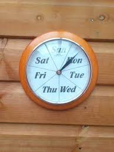

Clock with days of the week

With Sunday at the top, (and zero degrees at the top) the angles are:

| Day of week | Angle° | Sine | Cosine |
| --- | --- | --- | --- |
| Sunday | 0 | 0.000 | 1.000 |
| Monday | 51 | 0.782 | 0.623 |
| Tuesday | 103 | 0.975 | -0.223 |
| Wednesday | 154 | 0.434 | -0.901 |
| Thursday | 206 | -0.434 | -0.901 |
| Friday | 257 | -0.975 | -0.223 |
| Saturday | 309 | -0.782 | 0.623 |

The distance is $sqrt((0.000 - -0.975)^2 + (1.000 - -0.223)^2 ) = 1.564$

This result is unambiguous and does not depend which day is assigned to zero degrees.

#### Harmonic chart

The *Harmonic* tab in the card shows x-y scatter plots of any sinusoids. These sinusoids produce ring-like structures. Each encoded variable is allocated its own radius. The full-screen version of the chart provides a legend.

The buttons determine which types of temporal variable to encode in this way.